# Some visuals

Michiel van Eldik

2021-07-12

**Back to main**

# **1. Introduction**

This part shows some of the final preparations and data exploration through some visualizations.

```r
library(car)
library(dplyr)
library(ggplot2)
library(stargazer)
```

# **2. Final touches before visuals**

A few minor adjustments had to be made in order to start exploring the data.

Firstly, we turn variables from string to a factor format.

```r
cols <- c("bef_message_bool",
          "max_price_disc",
          "item_count_disc",
          "urbanity_disc",
          "freight_issue_bool",
          "review_score",
          "north",
          "northeast",
          "centerwest",
          "south",
          "southeast",
          "y_2016",
          "y_2017",
          "y_2018",
          "year",
          "top2box",
          "experience_goods",
          "search_goods",
          "intimate_goods",
          "review_sent_wknd",
          "review_answer_wknd",
          "sent_sun",
          "sent_mon",
          "sent_tue",
          "sent_wed",
          "sent_thu",
          "sent_fri",
          "sent_sat",
          "title_bool",
          "title_or_message",
          "title_and_message",
          "title_nor_message")

# apply as factor to all columns named above
brazil_df[,cols] <- lapply(brazil_df[cols], function(x) as.factor(x))

# Fix order
brazil_df <- brazil_df %>%
  mutate(item_count_disc = factor(item_count_disc,
                                  levels = c("single", "multiple", "large")))
# fix order
brazil_df <- brazil_df %>%
  mutate(hdi_class_col = factor(hdi_class_col, levels = c("low_medium",
                                                          "high",
                                                          "very high")))
```

Case wise deletion for missingness in relevant variables.

```r
brazil_df <- brazil_df %>%
  filter(order_status == "delivered")

brazil_df <- brazil_df %>%
  filter(! is.na(product_category_name))

brazil_df <- brazil_df %>%
  filter(!is.na(bef_message_bool))

brazil_df <- brazil_df %>%
  filter(!is.na(diff_est_deliv))

brazil_df <- brazil_df %>%
  mutate(item_count_bin = ifelse(item_count_disc == "single", 1, 0))

brazil_df <- brazil_df %>%
  filter(!is.na(product_height_cm))
```

```r
cats <- as.character(levels(brazil_df$product_category_name))
nrep <- rep(0, length(cats))
prod_uniques <- as.data.frame(nrep, cats)
prod_uniques$median_approx <- 0
counter <- 1
for (i in levels(brazil_df$product_category_name)) {
  prod_uniques[counter,1] <- length(unique(brazil_df[brazil_df$product_category_name == i,]$product_id.y))
  counter <- counter + 1
}
```

Mean centering continuous variables for interpretation purposes.

```r
center_scale <- function(x) {
  scale(x, scale = FALSE)
}

brazil_df$mc_new_idhm <- center_scale(brazil_df$new_idhm)
brazil_df$mc_new_young_ratio <- center_scale(brazil_df$new_young_ratio)
brazil_df$new_urbanity <- center_scale(brazil_df$new_urbanity)

stargazer(brazil_df[brazil_df$udh_indicator == 1,c("new_idhm", "new_young_ratio")],
          brazil_df[brazil_df$udh_indicator == 0,c("new_idhm", "new_young_ratio")],
          flip = TRUE,
          type = "text")
```

```
##
## ==================================
## Statistic new_idhm new_young_ratio
## ----------------------------------
## N          58,539      58,539
## Mean       0.782        0.192
## St. Dev.   0.099        0.045
## Min        0.534        0.081
## Pctl(25)   0.694        0.157
## Pctl(75)   0.863        0.225
## Max        0.965        0.364
## ----------------------------------
##
## ==================================
## Statistic new_idhm new_young_ratio
## ----------------------------------
## N          36,000      36,000
## Mean       0.735        0.203
## St. Dev.   0.058        0.022
## Min        0.484        0.130
## Pctl(25)   0.709        0.187
## Pctl(75)   0.778        0.214
## Max        0.854        0.333
## ----------------------------------
```

```r
stargazer(summary(brazil_df[,"bef_message_bool"]), type = "text")
```

```
##
## =============
## 0        1
## -------------
## 56,100 38,439
## -------------
```

# **3. Visualizations**

Check: how many people have more than 2 items per order?

```r
# PART 2: FIRST INSIGHTS
################################################################################


more_than_2 <- brazil_df %>%
  group_by(customer_unique_id) %>%
  summarise(count = n())
more_than_2 <- more_than_2 %>%
  mutate(two_or_one = ifelse(count >2, 0, 1),
         one = ifelse(count == 1, 1, 0))


mean(more_than_2$two_or_one)
```

```
## [1] 0.9977861
```

```r
mean(more_than_2$one)
```

```
## [1] 0.9720814
```

The first visual has the purpose of showing us state counts of Human Development category per region. This is relevant because, if there are shortages or major imbalances, it might affect the results from analyses.

```r
pop <- brazil_df %>%
  group_by(region, hdi_class_col, bef_message_bool) %>%
  summarise(n = n())
zero_low <- sum(pop[pop$hdi_class_col == "low_medium" & pop$bef_message_bool == 0,]$n)
zero_high <- sum(pop[pop$hdi_class_col == "high" & pop$bef_message_bool == 0,]$n)
zero_veryhigh <- sum(pop[pop$hdi_class_col == "very high" & pop$bef_message_bool == 0,]$n)

one_low <- sum(pop[pop$hdi_class_col == "low_medium" & pop$bef_message_bool == 1,]$n)
one_high <- sum(pop[pop$hdi_class_col == "high" & pop$bef_message_bool == 1,]$n)
one_veryhigh <- sum(pop[pop$hdi_class_col == "very high" & pop$bef_message_bool == 1,]$n)

pop[nrow(pop)+1,] <- NA
pop[nrow(pop)+1,] <- NA
pop[nrow(pop)+1,] <- NA
pop[nrow(pop)+1,] <- NA
pop[nrow(pop)+1,] <- NA
pop[nrow(pop)+1,] <- NA


# Add Full dist
pop <- pop %>%
  mutate(region = as.character(region),
         hdi_class_col = as.character(hdi_class_col),
         bef_message_bool = as.character(bef_message_bool))

pop[31:36,1] <- "full"
pop[31:36,2] <- c("low_medium", "low_medium",
                  "high", "high",
                  "very high", "very high")
pop[31:36,3] <- c("0", "1",
                  "0", "1",
                  "0", "1")
pop[31:36,4] <- c(zero_low, one_low,
                  zero_high, one_high,
                  zero_veryhigh, one_veryhigh)
pop <- pop %>%
  mutate(region = as.factor(region),
         hdi_class_col = as.factor(hdi_class_col),
         bef_message_bool = as.factor(bef_message_bool))

pop <- pop %>%
  mutate(region = factor(region, levels = c("centerwest",
                                            "north",
                                            "northeast",
                                            "south",
                                            "southeast",
                                            "full")),
         hdi_class_col = factor(hdi_class_col, levels = c("low_medium",
                                                          "high",
                                                          "very high")))
to_go <- c(2,
           4,
           6,
           8,
           10,
           12,
           14,
           16,
           18,
           20,
           22,
           24,
           26,
           28,
           30,
           32,
           34,
           36)

new_vec <- rep("0", length(to_go))

counter <- 1
for (i in to_go){
  outcome <- pop[i,"n"] / (pop[i,"n"] +  pop[i-1,"n"])
  new_vec[counter] <- outcome
  counter <- counter + 1
}

round(new_vec[[2]], digits = 2)
```

```
## [1] 0.42
```

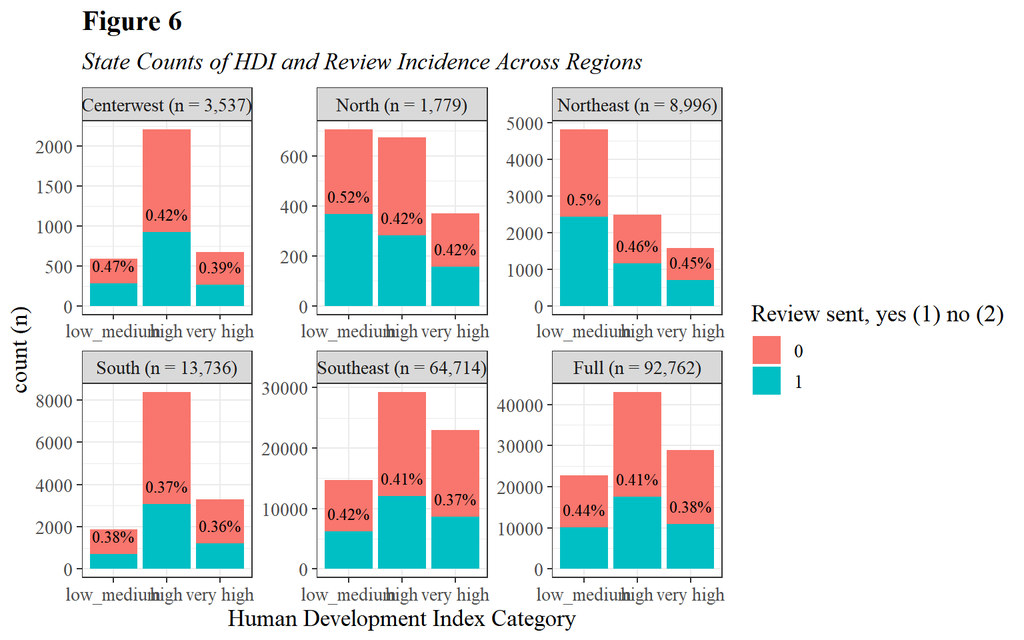

```r
test <- c("", paste(as.character(round(new_vec[[1]], digits = 2)), "%", sep = ""),
          "", paste(as.character(round(new_vec[[2]], digits = 2)), "%", sep = ""),
          "", paste(as.character(round(new_vec[[3]], digits = 2)), "%", sep = ""),
          "", paste(as.character(round(new_vec[[4]], digits = 2)), "%", sep = ""),
          "", paste(as.character(round(new_vec[[5]], digits = 2)), "%", sep = ""),
          "", paste(as.character(round(new_vec[[6]], digits = 2)), "%", sep = ""),
          "", paste(as.character(round(new_vec[[7]], digits = 2)), "%", sep = ""),
          "", paste(as.character(round(new_vec[[8]], digits = 2)), "%", sep = ""),
          "", paste(as.character(round(new_vec[[9]], digits = 2)), "%", sep = ""),
          "", paste(as.character(round(new_vec[[10]], digits = 2)), "%", sep = ""),
          "", paste(as.character(round(new_vec[[11]], digits = 2)), "%", sep = ""),
          "", paste(as.character(round(new_vec[[12]], digits = 2)), "%", sep = ""),
          "", paste(as.character(round(new_vec[[13]], digits = 2)), "%", sep = ""),
          "", paste(as.character(round(new_vec[[14]], digits = 2)), "%", sep = ""),
          "", paste(as.character(round(new_vec[[15]], digits = 2)), "%", sep = ""),
          "", paste(as.character(round(new_vec[[16]], digits = 2)), "%", sep = ""),
          "", paste(as.character(round(new_vec[[17]], digits = 2)), "%", sep = ""),
          "", paste(as.character(round(new_vec[[18]], digits = 2)), "%", sep = ""))

windowsFonts(`Times New Roman` = windowsFont("Times New Roman"))

# Do visual again
ggplot(pop, aes(fill=bef_message_bool, y=n, x=hdi_class_col)) +
  geom_bar(position="stack", stat="identity") +
  geom_text(size = 3.3, aes(label = test, family = "serif"), vjust = -1) +
  ylab("count (n)") +
  xlab("Human Development Index Category") +
  theme_bw() +
  labs(title = expression(bold("Figure 6")),
       subtitle = expression(italic("State Counts of HDI and Review Incidence Across Regions"))) +
  labs(fill = "Review sent, yes (1) no (2)") +
  theme(text=element_text(size=13,  family="Times New Roman")) +
  facet_wrap( ~ region,
              scales = "free",
              labeller =labeller(region = c(
                "centerwest" = "Centerwest (n = 3,537)",
                "north" = "North (n = 1,779)",
                "northeast" = "Northeast (n = 8,996)",
                "south" = "South (n = 13,736)",
                "southeast" = "Southeast (n = 64,714)",
                "full" = "Full (n = 92,762)")))
```

One of the DVs in the research is “review length” and it’s good to have a look at how it is distributed.

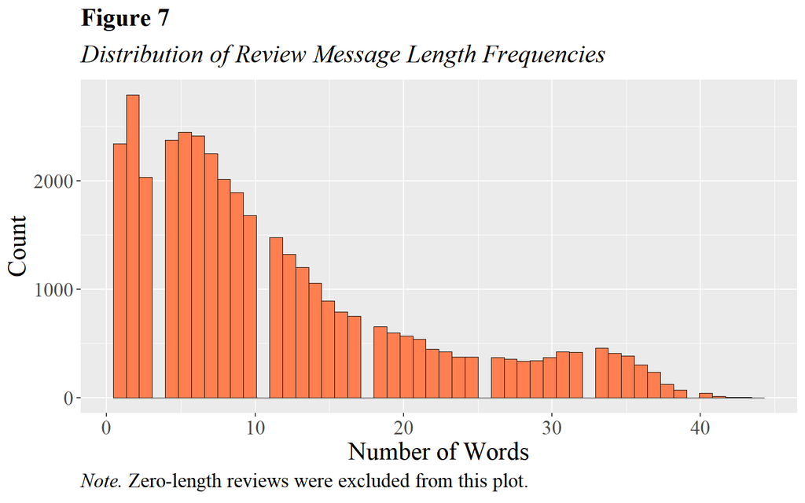

```r
note = expression(paste(italic("Note. "), "Zero-length reviews were excluded from this plot."))
ggplot(brazil_df[brazil_df$bef_message_bool == 1,], aes(x= bef_nwords)) +
  geom_histogram(color="black", fill="coral", size = 0.1, bins = 50) +
  labs(caption = note) +
  labs(title = expression(bold("Figure 7")),
       subtitle = expression(italic("Distribution of Review Message Length Frequencies"))) +
  xlab("Number of Words") + ylab("Count") +
  theme(text = element_text(family = "Times New Roman", size = 18),
        plot.title = element_text(size = 18),
        plot.subtitle = element_text(size = 18),
        plot.caption = element_text(hjust = 0))
```

Let’s have a look at urbanity and Human Development rate across metro/non-metro regions.

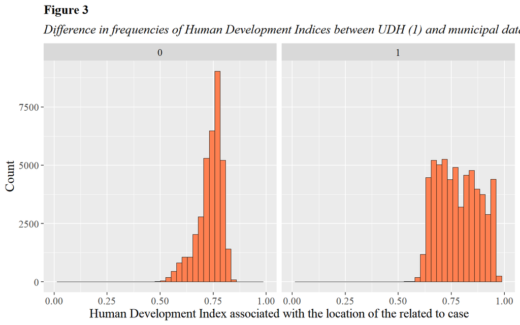

```r
ggplot(brazil_df, aes(x= new_idhm)) +
  geom_histogram(color="black", fill="coral", size = 0.1, bins = 40) +
  facet_wrap(~udh_indicator) +
  xlim(0, 1.00) +
  labs(title = expression(bold("Figure 3")),
       subtitle = expression(italic("Difference in frequencies of Human Development Indices between UDH (1) and municipal data (0) cases"))) +
  xlab("Human Development Index associated with the location of the related to case") + ylab("Count") +
  theme(text = element_text(family = "Times New Roman", size = 14),
        plot.title = element_text(size = 14),
        plot.subtitle = element_text(size = 14))
```

[figure not shown]

```r
ggplot(brazil_df, aes(x= new_urbanity)) +
  geom_histogram(color="black", fill="coral", size = 0.1) +
  facet_wrap(~udh_indicator) +
  labs(title = expression(bold("Figure 4")),
       subtitle = expression(italic("Difference in frequencies of urbanicity cases between UDH (1) and municipal data (0) cases"))) +
  xlab("Ratio of urban population to total population of a single spatial unit associated with a case") + ylab("Count") +
  theme(text = element_text(family = "Times New Roman", size = 14),
        plot.title = element_text(size = 14),
        plot.subtitle = element_text(size = 14))
```

Full plot of the data points projected onto the map of Brazil.

```r
library(geobr)
library(crul)
library(extrafont)
```

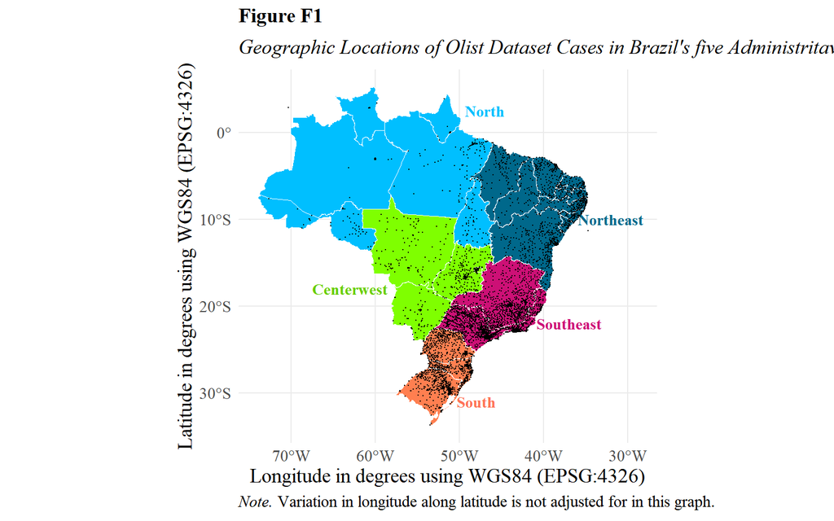

```r
# The one
note = expression(paste(italic("Note. "), "Variation in longitude along latitude is not adjusted for in this graph."))
note_2 = expression(paste(italic("Note. "), "Variation in longitude along latitude is not adjusted for in this graph. Furthermore, no map was available for this data."))
ggplot() + geom_sf(data=state,
                   fill=(ifelse(state$name_region == "Norte", "deepskyblue",
                                ifelse(state$name_region == "Nordeste", "deepskyblue4",
                                       ifelse(state$name_region == "Sul", "coral",
                                              ifelse(state$name_region == "Sudeste", "deeppink3", "chartreuse"))))), color="white", size=.15, show.legend = FALSE) +
  labs(title = expression(bold("Figure F1")),
       subtitle = expression(italic("Geographic Locations of Olist Dataset Cases in Brazil's five Administritave Regions"))) +
  theme_minimal() +
  labs(caption = note) +
  theme(text = element_text(family = "Times New Roman", size = 14),
        plot.title = element_text(size = 14),
        plot.subtitle = element_text(size = 14),
        plot.caption = element_text(hjust = 0)) +
  annotate("text", x = -48, y = -31, label = "South", col = "coral1", family = "Times New Roman", fontface = "bold") +
  annotate("text", x = -63, y = -18, label = "Centerwest", col = "chartreuse3", family = "Times New Roman", fontface = "bold") +
  annotate("text", x = -47, y = 2.5, label = "North", col = "deepskyblue1", family = "Times New Roman", fontface = "bold") +
  annotate("text", x = -32, y = -10, label = "Northeast", col = "deepskyblue4", family = "Times New Roman", fontface = "bold") +
  annotate("text", x = -37, y = -22, label = "Southeast", col = "deeppink3", family = "Times New Roman", fontface = "bold") +

  xlab("Longitude in degrees using WGS84 (EPSG:4326)") + ylab("Latitude in degrees using WGS84 (EPSG:4326)") +
  geom_point(aes(
    y = brazil_df[brazil_df$centroid_lat < 10 & brazil_df$centroid_long < -30 ,]$centroid_lat,
    x =  brazil_df[brazil_df$centroid_lat < 10 & brazil_df$centroid_long < -30 ,]$centroid_long), size = 0.07) + theme(legend.position="bottom")
```

Now, let’s zoom in to some of the metropolitan areas. First, load the map. In this case, the red dots represent external (census) data points and the black dots represent the review data set (Olist) data points. Note that both data sets were connected by finding two points that are closest to each other for all points.

Sao Paulo.

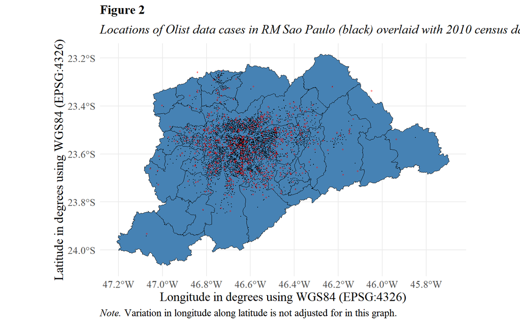

```r
ggplot() +
  geom_sf(data=metros[metros$name_metro == "RM São Paulo",], fill="steelblue", color="black", size=.2, show.legend = FALSE) +
  labs(title = expression(bold("Figure 2")),
       subtitle = expression(italic("Locations of Olist data cases in RM Sao Paulo (black) overlaid with 2010 census data (red)"))) +
  theme_minimal() +
  labs(caption = note) +
  theme(text = element_text(family = "Times New Roman", size = 14),
        plot.title = element_text(size = 14),
        plot.subtitle = element_text(size = 14),
        plot.caption = element_text(hjust = 0)) +
  xlab("Longitude in degrees using WGS84 (EPSG:4326)") +
  ylab("Latitude in degrees using WGS84 (EPSG:4326)") +
  geom_point(aes(
    y = brazil_df[brazil_df$metro == "sao_paulo"  & brazil_df$udh.lat < -23.2,]$centroid_lat,
    x =  brazil_df[brazil_df$metro == "sao_paulo"  & brazil_df$udh.lat < -23.2,]$centroid_long), col = "black", size = 0.01) +
  geom_point(aes(
    y = brazil_df[brazil_df$metro == "sao_paulo" & brazil_df$udh.lat < -23.2,]$udh.lat,
    x =  brazil_df[brazil_df$metro == "sao_paulo"  & brazil_df$udh.lat < -23.2,]$udh.long), col = "red", size = 0.2, shape = 23)
```

Rio de Janeiro.

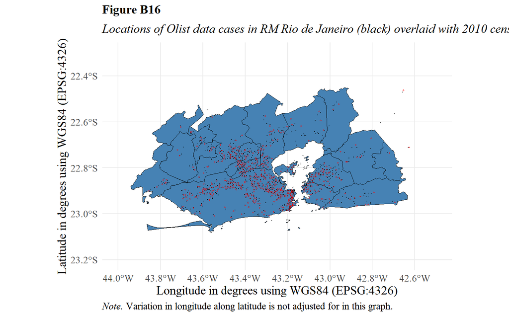

```r
ggplot() +
  geom_sf(data=metros[metros$name_metro == "RM Rio de Janeiro",], fill="steelblue", color="black", size=.2, show.legend = FALSE) +
  labs(title = expression(bold("Figure B16")),
       subtitle = expression(italic("Locations of Olist data cases in RM Rio de Janeiro (black) overlaid with 2010 census data (red)"))) +
  theme_minimal() +
  labs(caption = note) +
  theme(text = element_text(family = "Times New Roman", size = 14),
        plot.title = element_text(size = 14),
        plot.subtitle = element_text(size = 14),
        plot.caption = element_text(hjust = 0)) +
  xlab("Longitude in degrees using WGS84 (EPSG:4326)") +
  ylab("Latitude in degrees using WGS84 (EPSG:4326)") +
  geom_point(aes(
    y = brazil_df[brazil_df$metro == "rio_de_janeiro",]$centroid_lat,
    x =  brazil_df[brazil_df$metro == "rio_de_janeiro",]$centroid_long), col = "black", size = 0.01) +
  geom_point(aes(
    y = brazil_df[brazil_df$metro == "rio_de_janeiro" ,]$udh.lat,
    x =  brazil_df[brazil_df$metro == "rio_de_janeiro",]$udh.long), col = "red", size = 0.2, shape = 23) +
  xlim(-44,-42.5) +
  ylim(-23.2, -22.3)
```

**Back to main**